# Analysing Wearable Training Data

Sujata Emani

July 21, 2018

## Summary

This is a review and analysis of data from a wearable device. The Analysis will entail using data from accelerometers on the belt, forearm, arm, and dumbell of 6 participants to determine how well they do a particular activity. They were asked to perform barbell lifts correctly and incorrectly in 5 different ways.

```r
library(knitr)
library(caret)
library(rpart)
library(rattle)
library(randomForest)
library(gbm)
```

### Loading the Data

```r
train_url <-"https://d396qusza40orc.cloudfront.net/predmachlearn/pml-training.csv"
test_url <- "https://d396qusza40orc.cloudfront.net/predmachlearn/pml-testing.csv"
training <- read.csv(url(train_url), na.strings = c("NA", "#DIV/0!", ""))
testing <- read.csv(url(test_url), na.strings = c("NA", "#DIV/0!", ""))
```

### Creating a training and data set for internal test

```r
set.seed(98765)
inTrain <- createDataPartition(training$classe, p = 0.65, list = FALSE)
myTrainingSet <- training[inTrain, ]
myTestingSet <- training[-inTrain, ]
dim(myTrainingSet); dim(myTestingSet)
```

```
## [1] 12757   160
```

```
## [1] 6865  160
```

```r
## clear near zero variance columns from myTrainingSet
nearZero <- nearZeroVar(myTrainingSet, saveMetrics = TRUE)
myTrainingSet <- myTrainingSet[, nearZero$nzv == FALSE]

## clear near zero variance columns from myTestingSet
nearZero <- nearZeroVar(myTestingSet, saveMetrics = TRUE)
myTestingSet <- myTestingSet[, nearZero$nzv == FALSE]
```

### Cleaning up the Data

There are a lot of NA in each of the measured parameters. It’s best to analyze the columns with fewer than 40% of NAs.

```r
myTrainingSet <- myTrainingSet[c(-1)]
rmNATrainingSet <- myTrainingSet
for(i in 1:length(myTrainingSet)){
    if(sum(is.na(myTrainingSet[,i]))/nrow(myTrainingSet) >= 0.4){
        for(j in 1:length(rmNATrainingSet)){
            if(length(grep(names(myTrainingSet[i]), names(rmNATrainingSet)[j])) == 1){
                rmNATrainingSet <- rmNATrainingSet[,-j]
            }
        }
    }
}
myTrainingSet <- rmNATrainingSet
rm(rmNATrainingSet)
```

### Imputing the Missing NAs for the remaining columns

The variables which have NAs can be imputed with the mean of the column.

```r
suppressWarnings(
    for(i in 1:length(myTrainingSet)){
        current_mean <- mean(myTrainingSet[,i], na.rm = TRUE)
        currentVector <- myTrainingSet[,i]
        myTrainingSet[,i][is.na(currentVector)] = current_mean
})
```

### Transforming the Data sets to be the same format

```r
## checking is the classes of each column in the data sets are the same
myTestingSet <- myTestingSet[colnames(myTrainingSet)]
testing <- testing[colnames(myTrainingSet[,-58])]
class_compare <- data.frame(y1 = sapply(testing,class), y2 = sapply(myTrainingSet[,-58],class))
dim(myTestingSet); dim(testing)
```

```
## [1] 6865   58
```

```
## [1] 20 57
```

```r
## the classes are not all the same, so make them the same.
for(i in 1:length(myTrainingSet)){
    for(j in 1:length(testing)) {
        if(length(grep(names(myTrainingSet[i]), names(testing)[j])) == 1){
            class(testing[j]) <-class(myTrainingSet[i])
        }
    }
}
## combining the data sets
testing <- rbind(myTrainingSet[2, -58], testing)
testing <- testing[-1,]
```

## Prediction Modeling

### Predicting with Rpart

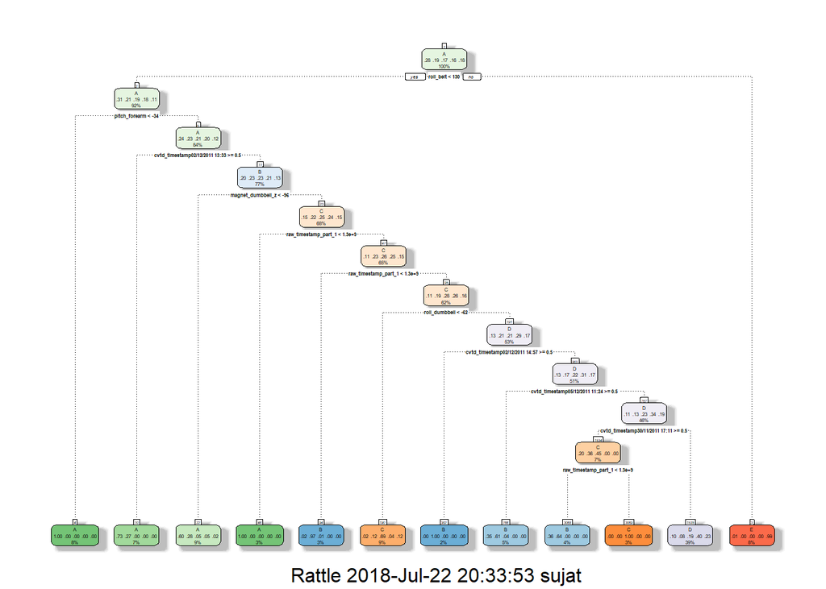

```r
set.seed(98765)
modFit_rpart <- train(classe~. , data = myTrainingSet, method = "rpart")
fancyRpartPlot(modFit_rpart$finalModel)
```

### Reviewing the Accuracy with rpart

```r
cfm_rpart<- confusionMatrix(myTestingSet$classe, predict(modFit_rpart, myTestingSet))
cfm_rpart
```

```
## Confusion Matrix and Statistics
##
##           Reference
## Prediction    A    B    C    D    E
##          A 1445  235   16  250    7
##          B  288  748   74  218    0
##          C   28   14  641  514    0
##          D   39    0   43 1043    0
##          E   14    0   66  611  571
##
## Overall Statistics
##
##                Accuracy : 0.6479
##                  95% CI : (0.6365, 0.6592)
##     No Information Rate : 0.384
##     P-Value [Acc > NIR] : < 2.2e-16
##
##                   Kappa : 0.5582
##  Mcnemar's Test P-Value : NA
##
## Statistics by Class:
##
##                      Class: A Class: B Class: C Class: D Class: E
## Sensitivity            0.7966   0.7503  0.76310   0.3957  0.98789
## Specificity            0.8994   0.9012  0.90772   0.9806  0.89009
## Pos Pred Value         0.7399   0.5633  0.53551   0.9271  0.45246
## Neg Pred Value         0.9249   0.9550  0.96489   0.7225  0.99875
## Prevalence             0.2642   0.1452  0.12236   0.3840  0.08420
## Detection Rate         0.2105   0.1090  0.09337   0.1519  0.08318
## Detection Prevalence   0.2845   0.1934  0.17436   0.1639  0.18383
## Balanced Accuracy      0.8480   0.8257  0.83541   0.6881  0.93899
```

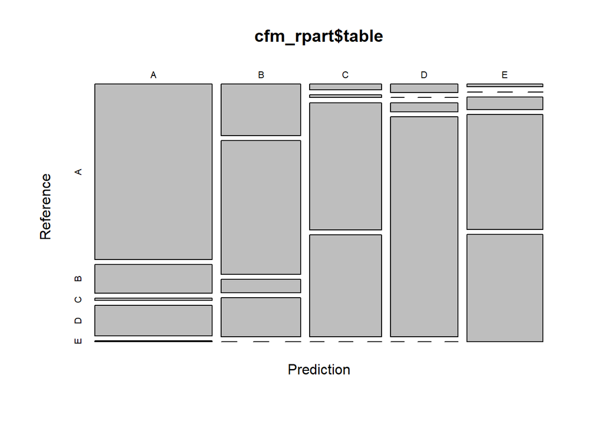

```r
plot(cfm_rpart$table)
```

The Recursive Partitioning Method indicates an Accuracy Result of 64.79%.

### Prediction with Random Forests

```r
set.seed(98765)
modFit_rf <- randomForest(classe~., data = myTrainingSet)
```

### Reviewing the Accuracy with Random Forests

```r
predict_rf <- predict(modFit_rf, myTestingSet)
cfm_rf<- confusionMatrix(myTestingSet$classe, predict_rf)
cfm_rf
```

```
## Confusion Matrix and Statistics
##
##           Reference
## Prediction    A    B    C    D    E
##          A 1953    0    0    0    0
##          B    0 1328    0    0    0
##          C    0    1 1196    0    0
##          D    0    0    7 1117    1
##          E    0    0    0    0 1262
##
## Overall Statistics
##
##                Accuracy : 0.9987
##                  95% CI : (0.9975, 0.9994)
##     No Information Rate : 0.2845
##     P-Value [Acc > NIR] : < 2.2e-16
##
##                   Kappa : 0.9983
##  Mcnemar's Test P-Value : NA
##
## Statistics by Class:
##
##                      Class: A Class: B Class: C Class: D Class: E
## Sensitivity            1.0000   0.9992   0.9942   1.0000   0.9992
## Specificity            1.0000   1.0000   0.9998   0.9986   1.0000
## Pos Pred Value         1.0000   1.0000   0.9992   0.9929   1.0000
## Neg Pred Value         1.0000   0.9998   0.9988   1.0000   0.9998
## Prevalence             0.2845   0.1936   0.1752   0.1627   0.1840
## Detection Rate         0.2845   0.1934   0.1742   0.1627   0.1838
## Detection Prevalence   0.2845   0.1934   0.1744   0.1639   0.1838
## Balanced Accuracy      1.0000   0.9996   0.9970   0.9993   0.9996
```

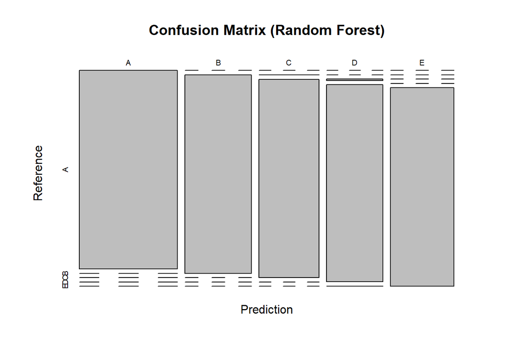

```r
plot(cfm_rf$table, main = "Confusion Matrix (Random Forest)")
```

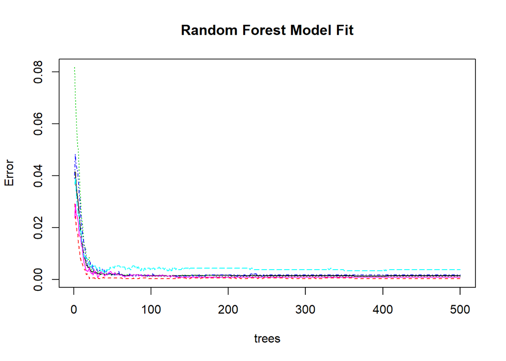

```r
plot(modFit_rf, main = "Random Forest Model Fit")
```

The Random Forest indicates an Accuracy result of 99.87%. The accuracy exceeds the Recursive Partitioning Method.

### Prediction utilizing the Gradient Boosting Method

```r
set.seed(98765)
control <- trainControl(method = "repeatedcv",number = 5, repeats = 1)
modelFit_gbm <- train(classe ~ ., data = myTrainingSet, method = "gbm", trControl = control, verbose = FALSE)
```

### Reviewing the Accuracy based on GBM

```r
predictGbm <- predict(modelFit_gbm, newdata = myTestingSet)
cfm_gbm<- confusionMatrix(myTestingSet$classe, predictGbm)
cfm_gbm
```

```
## Confusion Matrix and Statistics
##
##           Reference
## Prediction    A    B    C    D    E
##          A 1953    0    0    0    0
##          B    4 1320    4    0    0
##          C    0    3 1191    3    0
##          D    0    0   10 1115    0
##          E    0    0    0    4 1258
##
## Overall Statistics
##
##                Accuracy : 0.9959
##                  95% CI : (0.9941, 0.9973)
##     No Information Rate : 0.2851
##     P-Value [Acc > NIR] : < 2.2e-16
##
##                   Kappa : 0.9948
##  Mcnemar's Test P-Value : NA
##
## Statistics by Class:
##
##                      Class: A Class: B Class: C Class: D Class: E
## Sensitivity            0.9980   0.9977   0.9884   0.9938   1.0000
## Specificity            1.0000   0.9986   0.9989   0.9983   0.9993
## Pos Pred Value         1.0000   0.9940   0.9950   0.9911   0.9968
## Neg Pred Value         0.9992   0.9995   0.9975   0.9988   1.0000
## Prevalence             0.2851   0.1927   0.1755   0.1634   0.1832
## Detection Rate         0.2845   0.1923   0.1735   0.1624   0.1832
## Detection Prevalence   0.2845   0.1934   0.1744   0.1639   0.1838
## Balanced Accuracy      0.9990   0.9981   0.9937   0.9960   0.9996
```

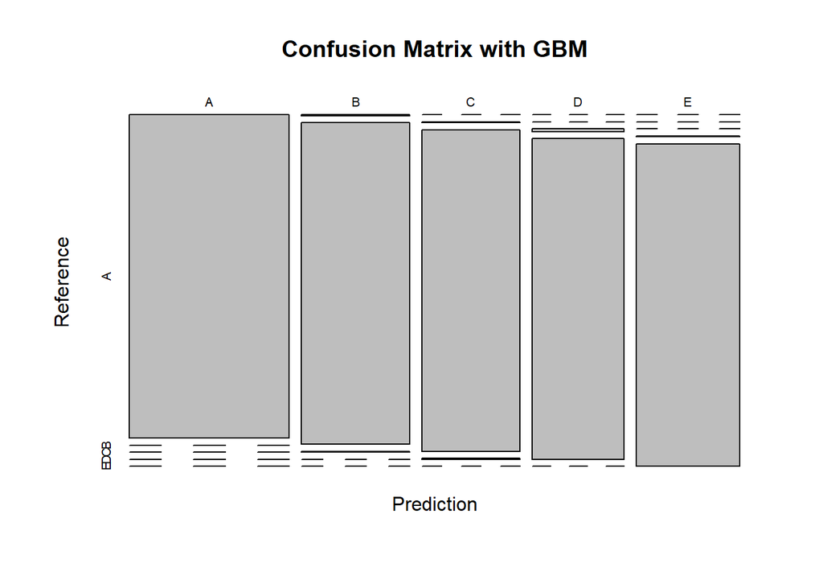

```r
plot(cfm_gbm$table, main = "Confusion Matrix with GBM")
```

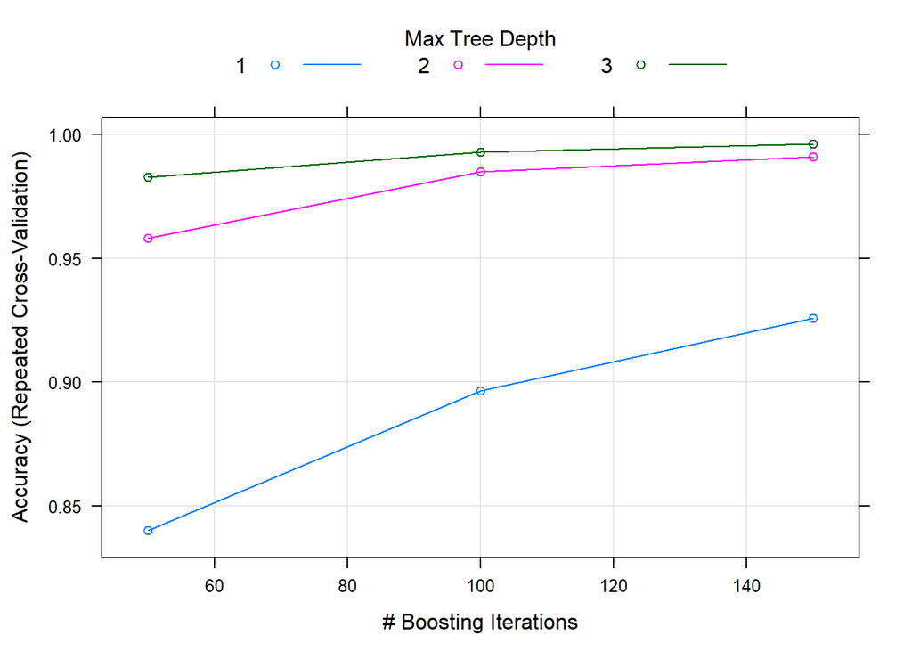

```r
plot(modelFit_gbm)
```

The data on Accuracy indicate that the Random Forest Learning Method is the best to move forward and evaluate the testing data.

```r
predict_testingData <- predict(modFit_rf, testing)
predict_testingData
```

```
##  1  2 31  4  5  6  7  8  9 10 11 12 13 14 15 16 17 18 19 20
##  B  A  B  A  A  E  D  B  A  A  B  C  B  A  E  E  A  B  B  B
## Levels: A B C D E
```

The Testing Data loaded from the website was evaluated utilizing the Random Forest Learning Model and the Predicted Results are shown above.

Citation for the Data utilized for this analysis.

Velloso, E.; Bulling, A.; Gellersen, H.; Ugulino, W.; Fuks, H. Qualitative Activity Recognition of Weight Lifting Exercises. Proceedings of 4th International Conference in Cooperation with SIGCHI (Augmented Human ’13) . Stuttgart, Germany: ACM SIGCHI, 2013.

Read more: http://groupware.les.inf.puc-rio.br/har#wle_paper_section#ixzz5LvqbNoEo